# Week 4: Importing and Exploring Data - Class Exercises

We first load the packages necessary for this exercise.

```python
import pandas as pd
import numpy as np
import matplotlib.pyplot as plt
import json
import requests
```

## 1. International Visitor Arrivals in Singapore

The file `tourist.csv` (available from `Canvas > Files > data`) contains monthly international visitor arrivals by length of stay from July to December in 2023, retrieved from the Singapore Department of Statistics.

Let’s start by reading in the data as df with the standard relative path.

```python
df = pd.read_csv('../data/tourist.csv')
```

**(A) Data Cleaning**

Examine the dataframe carefully.

Some of the categories in the column `Data Series` are overlapping. Remove the redundant entry.

Store the cleaned data frame as `df2`.

(**Hint**: Use `copy()` to create a new independent copy of the cleaned data frame. It makes sure we are not accidentally making changes to the original data frame. Read more [here](https://pandas.pydata.org/pandas-docs/stable/reference/api/pandas.DataFrame.copy.html).)

```python
# Type your code here:
df2 = df[df['Data Series'] != '15 Days & Over'].copy()
df2['Data Series'].nunique()
```

```
13
```

**(B) Summary Statistics**

```python
# Type your code here:
print(df2["2023 Dec"].sum())
```

```
1113842
```

**(C) Barplot**

Re-create, as much as you can, the horizontal bar chart below showing the distribution of tourists’ length of stay in December 2023.

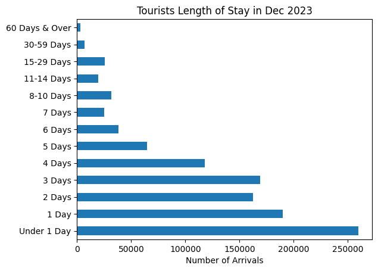

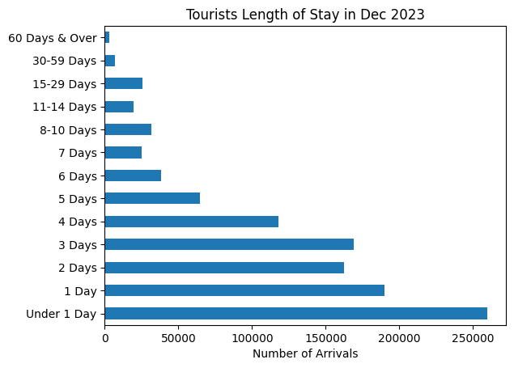

```python
# Type your code here:
df2.plot(x = 'Data Series', y = '2023 Dec', kind = 'barh', legend = False)
plt.title('Tourists Length of Stay in Dec 2023')
plt.xlabel('Number of Arrivals')
plt.ylabel('')
plt.show()
```

## 2. Pupil-Teacher Ratio

There are 5000+ data sets available on data.gov.sg.

In this exercise, practice querying and visualizing data on the Pupil-Teacher Ratio (PTR) in primary schools by year. Try reproducing the plot below.

https://data.gov.sg/datasets/d_bc5a1a10afedf7d25128dae1342c9556/view

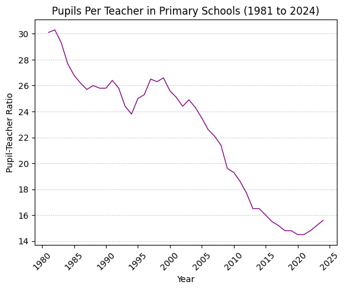

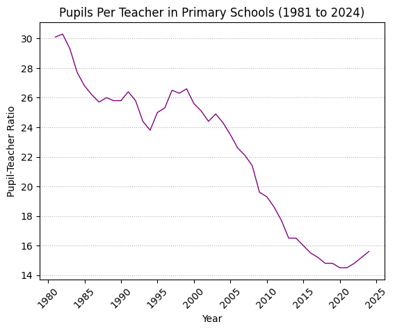

```python
# Type your code here:
import requests

dataset_id = "d_bc5a1a10afedf7d25128dae1342c9556"
url = "https://data.gov.sg/api/action/datastore_search?resource_id="  + dataset_id

response = requests.get(url)
response_json = response.json()
records = response_json["result"]["records"]
df = pd.DataFrame(records)

df['pupil_teacher_ratio'] = pd.to_numeric(df['pri_students_to_teachers'])
df['year'] = pd.to_numeric(df['year'])

df.plot(kind = 'line', x = 'year', y = 'pupil_teacher_ratio',
         linewidth = 1, color = 'purple', legend = False,
         title = 'Pupils Per Teacher in Primary Schools (1981 to 2024)',
         xlabel = 'Year', ylabel = 'Pupil-Teacher Ratio')
tick_values = list(range(1980, 2030, 5))
plt.xticks(ticks = tick_values, labels = tick_values, rotation = 45)
plt.grid(axis='y', linestyle = ':')
plt.show()
```